# Lecture 1

## `inlabru` for disease mapping

**The Model**

$$\begin{aligned}
y_i|\eta_t & \sim \text{Poisson}(E_i\lambda_i)\\
\text{log}(\lambda_i) = \color{red}{\boxed{\eta_i}} & = \color{red}{\boxed{\beta_0 + \beta_1\ c_i + \omega_i}}
\end{aligned}$$

```r
g = system.file("demodata/germany.graph",
                package="INLA")
Germany[1:3,]
```

```
  region         E  Y  x region.struct
1      1  7.965008  8 56             1
2      2 22.836219 22 65             2
3      3 22.094716 19 50             3
```

**The code**

```r
# define model component
cmp =  ~ -1 + beta0(1) + beta1(x, model = "linear") +
  space(region, model = "bym2", graph = g)

# define model predictor
eta = Y ~ beta0 + beta1 + space

# build the observation model
lik = bru_obs(formula = eta,
              family = "poisson",
              E = E,
              data = Germany)

# fit the model
fit = bru(cmp, lik)
```

## `inlabru` for disease mapping

**The Model**

$$\begin{aligned}
\color{red}{\boxed{y_i|\eta_t}} & \color{red}{\boxed{\sim \text{Poisson}(E_i\lambda_i)}}\\
\text{log}(\lambda_i) = \eta_i & = \beta_0 + \beta_1\ c_i + \omega_i
\end{aligned}$$

```r
g = system.file("demodata/germany.graph",
                package="INLA")
Germany[1:3,]
```

```
  region         E  Y  x region.struct
1      1  7.965008  8 56             1
2      2 22.836219 22 65             2
3      3 22.094716 19 50             3
```

**The code**

```r
# define model component
cmp =  ~ -1 + beta0(1) + beta1(x, model = "linear") +
  space(region, model = "bym2", graph = g)

# define model predictor
eta = Y ~ beta0 + beta1 + space

# build the observation model
lik = bru_obs(formula = eta,
              family = "poisson",
              E = E,
              data = Germany)

# fit the model
fit = bru(cmp, lik)
```

## `inlabru` for disease mapping

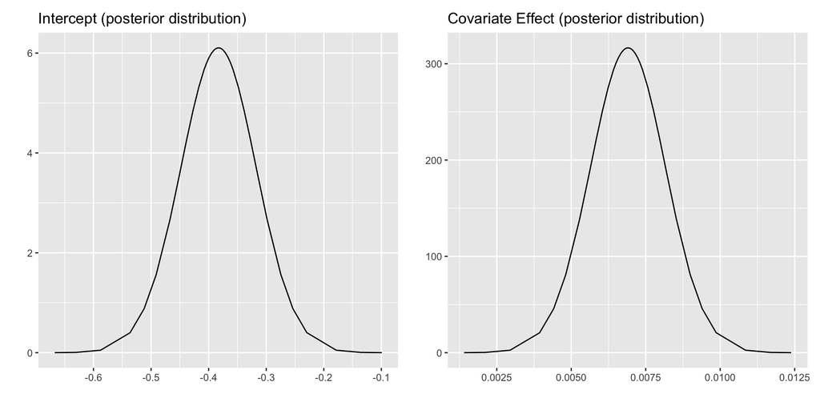

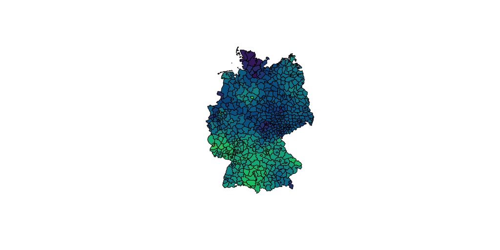

## Bayesian Geostatistics

Encounter probability of Pacific Cod (*Gadus macrocephalus*) from a trawl survey.

[interactive chart not shown]

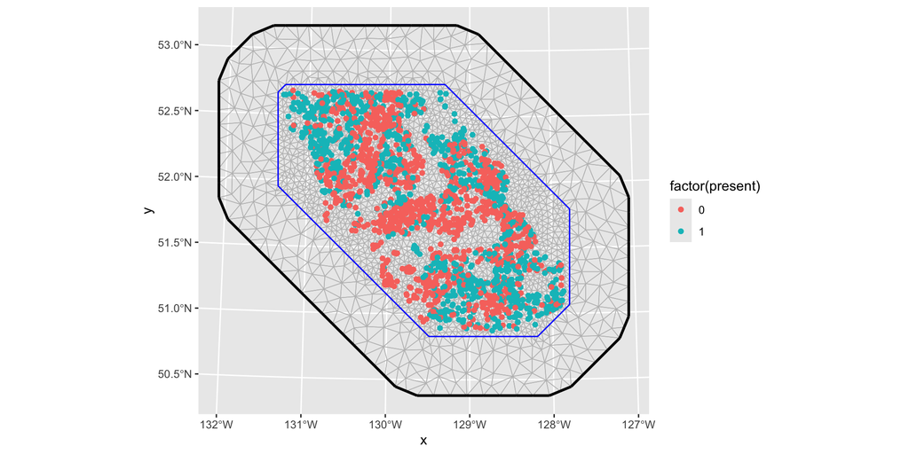

$y(s)$ Presence or absence in location $s$

## Bayesian Geostatistics

- **Stage 1** Model for the response
  $$y(s)|\eta(s)\sim\text{Binom}(1, p(s))$$
- **Stage 2** Latent field model
  $$\eta(s) = \text{logit}(p(s)) = \beta_0 + f( x(s)) + \omega(s)$$
- **Stage 3** Hyperparameters

## Bayesian Geostatistics

- **Stage 1** Model for the response
  $$y(s)|\eta(s)\sim\text{Binom}(1, p(s))$$
- **Stage 2** Latent field model
  $$\eta(s) = \text{logit}(p(s)) = \beta_0 + f( x(s)) + \omega(s)$$
  - A global intercept $\beta_0$
  - A smooth effect of covariate $x(s)$ (depth)
  - A Gaussian field $\omega(s)$ (will discuss this later..)
- **Stage 3** Hyperparameters

## `inlabru` for geostatistics

**The Model**

$$\begin{aligned}
y(s)|\eta(s) & \sim\text{Binom}(1, p(s))\\
\eta(s) & = \color{red}{\boxed{\beta_0}} + \color{red}{\boxed{ f(x(s))}} + \color{red}{\boxed{ \omega(s)}}\\
\end{aligned}$$

```r
df %>% select(depth, present) %>% print(n = 3)
```

```
Simple feature collection with 2143 features and 2 fields
Geometry type: POINT
Dimension:     XY
Bounding box:  xmin: 343.0617 ymin: 5635.893 xmax: 579.3681 ymax: 5839.019
Projected CRS: +proj=utm +zone=9 +datum=WGS84 +no_defs +type=crs +units=km
# A tibble: 2,143 × 3
  depth present            geometry
  <dbl>   <dbl>        <POINT [km]>
1   201       1 (446.4752 5793.426)
2   212       1 (446.4594 5800.136)
3   220       0 (448.5987 5801.687)
# ℹ 2,140 more rows
```

**The code**

```r
# define model component
cmp = ~ -1 + Intercept(1) +  depth_smooth(log(depth), model='rw2') +
  space(geometry, model = spde_model)

# define model predictor
eta = present ~ Intercept + depth_smooth + space

# build the observation model
lik = bru_obs(formula = eta,
              data = df,
              family = "binomial")

# fit the model
fit = bru(cmp, lik)
```

## `inlabru` for geostatistics

**The Model**

$$\begin{aligned}
y(s)|\eta(s) & \sim\text{Binom}(1, p(s))\\
\color{red}{\boxed{\eta(s)}} & = \color{red}{\boxed{\beta_0 + f(x(s)) + \omega(s)}}\\
\end{aligned}$$

```r
df %>% select(depth, present) %>% print(n = 3)
```

```
Simple feature collection with 2143 features and 2 fields
Geometry type: POINT
Dimension:     XY
Bounding box:  xmin: 343.0617 ymin: 5635.893 xmax: 579.3681 ymax: 5839.019
Projected CRS: +proj=utm +zone=9 +datum=WGS84 +no_defs +type=crs +units=km
# A tibble: 2,143 × 3
  depth present            geometry
  <dbl>   <dbl>        <POINT [km]>
1   201       1 (446.4752 5793.426)
2   212       1 (446.4594 5800.136)
3   220       0 (448.5987 5801.687)
# ℹ 2,140 more rows
```

**The code**

```r
# define model component
cmp = ~ -1 + Intercept(1) +  depth_smooth(log(depth), model='rw2') +
  space(geometry, model = spde_model)

# define model predictor
eta = present ~ Intercept + depth_smooth + space

# build the observation model
lik = bru_obs(formula = eta,
              data = df,
              family = "binomial")

# fit the model
fit = bru(cmp, lik)
```

## `inlabru` for geostatistics

**The Model**

$$\begin{aligned}
\color{red}{\boxed{y(s)|\eta(s)}} & \sim \color{red}{\boxed{\text{Binom}(1, p(s))}}\\
\eta(s) & = \beta_0 + f(x(s)) + \omega(s)\\
\end{aligned}$$

```r
df %>% select(depth, present) %>% print(n = 3)
```

```
Simple feature collection with 2143 features and 2 fields
Geometry type: POINT
Dimension:     XY
Bounding box:  xmin: 343.0617 ymin: 5635.893 xmax: 579.3681 ymax: 5839.019
Projected CRS: +proj=utm +zone=9 +datum=WGS84 +no_defs +type=crs +units=km
# A tibble: 2,143 × 3
  depth present            geometry
  <dbl>   <dbl>        <POINT [km]>
1   201       1 (446.4752 5793.426)
2   212       1 (446.4594 5800.136)
3   220       0 (448.5987 5801.687)
# ℹ 2,140 more rows
```

**The code**

```r
# define model component
cmp = ~ -1 + Intercept(1) +  depth_smooth(log(depth), model='rw2') +
  space(geometry, model = spde_model)

# define model predictor
eta = present ~ Intercept + depth_smooth + space

# build the observation model
lik = bru_obs(formula = eta,
              data = df,
              family = "binomial")

# fit the model
fit = bru(cmp, lik)
```

## `inlabru` for geostatistics

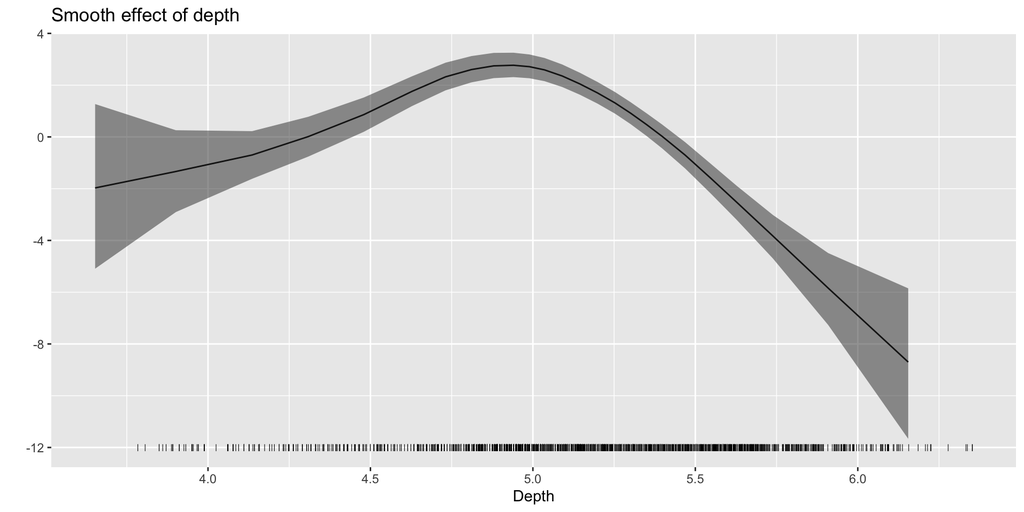

## `inlabru` for geostatistics

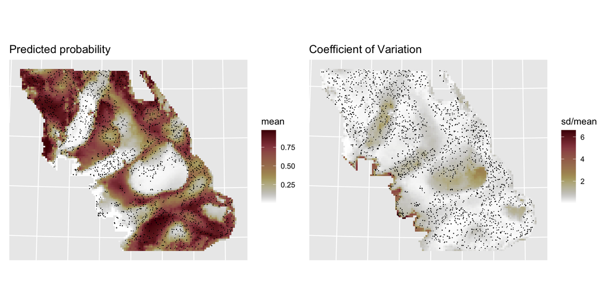

## Take home message!

- Many of the models you have used (and some you have never used but will learn about) are *just* special cases of the large class of Latent Gaussian models
- *inlabru* provides an efficient and unified way to fit all these models!